# Module 1 Homework: Chapter 2 Exercises, Problems 8, 9, and 10

## Ryan Waterman, 7/8/25

## Problem 8

This exercise relates to the College data set, which can be found in the file College.csv on the book website. It contains a number of variables for 777 different universities and colleges in the US. The variables are:

- Private : Public/private indicator
- Apps : Number of applications received
- Accept : Number of applicants accepted
- Enroll : Number of new students enrolled
- Top10perc : New students from top 10% of high school class
- Top25perc : New students from top 25% of high school class
- F.Undergrad : Number of full-time undergraduates
- P.Undergrad : Number of part-time undergraduates
- Outstate : Out-of-state tuition
- Room.Board : Room and board costs
- Books : Estimated book costs
- Personal : Estimated personal spending
- PhD : Percent of faculty with Ph.D.s
- Terminal : Percent of faculty with terminal degree
- S.F.Ratio : Student/faculty ratio
- perc.alumni : Percent of alumni who donate
- Expend : Instructional expenditure per student
- Grad.Rate : Graduation rate

Before reading the data into Python, it can be viewed in Excel or a text editor.

#### Part A

Use the pd.read_csv() function to read the data into Python. Call the loaded data college. Make sure that you have the directory set to the correct location for the data.

```python
import pandas as pd
```

```python
data_path = './data/College.csv'
```

```python
college = pd.read_csv(data_path)
college.head(5)
```

|  | Unnamed: 0 | Private | Apps | Accept | Enroll | Top10perc | Top25perc | F.Undergrad | P.Undergrad | Outstate | Room.Board | Books | Personal | PhD | Terminal | S.F.Ratio | perc.alumni | Expend | Grad.Rate |
| --- | --- | --- | --- | --- | --- | --- | --- | --- | --- | --- | --- | --- | --- | --- | --- | --- | --- | --- | --- |
| 0 | Abilene Christian University | Yes | 1660 | 1232 | 721 | 23 | 52 | 2885 | 537 | 7440 | 3300 | 450 | 2200 | 70 | 78 | 18.1 | 12 | 7041 | 60 |
| 1 | Adelphi University | Yes | 2186 | 1924 | 512 | 16 | 29 | 2683 | 1227 | 12280 | 6450 | 750 | 1500 | 29 | 30 | 12.2 | 16 | 10527 | 56 |
| 2 | Adrian College | Yes | 1428 | 1097 | 336 | 22 | 50 | 1036 | 99 | 11250 | 3750 | 400 | 1165 | 53 | 66 | 12.9 | 30 | 8735 | 54 |
| 3 | Agnes Scott College | Yes | 417 | 349 | 137 | 60 | 89 | 510 | 63 | 12960 | 5450 | 450 | 875 | 92 | 97 | 7.7 | 37 | 19016 | 59 |
| 4 | Alaska Pacific University | Yes | 193 | 146 | 55 | 16 | 44 | 249 | 869 | 7560 | 4120 | 800 | 1500 | 76 | 72 | 11.9 | 2 | 10922 | 15 |

#### Part B

Look at the data used in the notebook by creating and running a new cell with just the code college in it. You should notice that the first column is just the name of each university in a column named something like Unnamed: 0. We don’t really want pandas to treat this as data. However, it may be handy to have these names for later. Try the following commands and similarly look at the resulting data frames:

```
college2 = pd.read_csv('College.csv', index_col=0)
college3 = college.rename({'Unnamed: 0': 'College'},
axis=1)
college3 = college3.set_index('College')
```

This has used the first column in the file as an index for the data frame. This means that pandas has given each row a name corresponding to the appropriate university. Now you should see that the first data column is Private. Note that the names of the colleges appear on the left of the table. We also introduced a new python object above: a dictionary, which is specified by dictionary(key, value) pairs. Keep your modified version of the data with the following:

```
college = college3
```

```python
college2 = pd.read_csv(data_path, index_col=0)
college2.head(5)
```

|  | Private | Apps | Accept | Enroll | Top10perc | Top25perc | F.Undergrad | P.Undergrad | Outstate | Room.Board | Books | Personal | PhD | Terminal | S.F.Ratio | perc.alumni | Expend | Grad.Rate |
| --- | --- | --- | --- | --- | --- | --- | --- | --- | --- | --- | --- | --- | --- | --- | --- | --- | --- | --- |
| Abilene Christian University | Yes | 1660 | 1232 | 721 | 23 | 52 | 2885 | 537 | 7440 | 3300 | 450 | 2200 | 70 | 78 | 18.1 | 12 | 7041 | 60 |
| Adelphi University | Yes | 2186 | 1924 | 512 | 16 | 29 | 2683 | 1227 | 12280 | 6450 | 750 | 1500 | 29 | 30 | 12.2 | 16 | 10527 | 56 |
| Adrian College | Yes | 1428 | 1097 | 336 | 22 | 50 | 1036 | 99 | 11250 | 3750 | 400 | 1165 | 53 | 66 | 12.9 | 30 | 8735 | 54 |
| Agnes Scott College | Yes | 417 | 349 | 137 | 60 | 89 | 510 | 63 | 12960 | 5450 | 450 | 875 | 92 | 97 | 7.7 | 37 | 19016 | 59 |
| Alaska Pacific University | Yes | 193 | 146 | 55 | 16 | 44 | 249 | 869 | 7560 | 4120 | 800 | 1500 | 76 | 72 | 11.9 | 2 | 10922 | 15 |

```python
college3 = college.rename({'Unnamed: 0': 'College'}, axis = 1)
college3.head(5)
```

|  | College | Private | Apps | Accept | Enroll | Top10perc | Top25perc | F.Undergrad | P.Undergrad | Outstate | Room.Board | Books | Personal | PhD | Terminal | S.F.Ratio | perc.alumni | Expend | Grad.Rate |
| --- | --- | --- | --- | --- | --- | --- | --- | --- | --- | --- | --- | --- | --- | --- | --- | --- | --- | --- | --- |
| 0 | Abilene Christian University | Yes | 1660 | 1232 | 721 | 23 | 52 | 2885 | 537 | 7440 | 3300 | 450 | 2200 | 70 | 78 | 18.1 | 12 | 7041 | 60 |
| 1 | Adelphi University | Yes | 2186 | 1924 | 512 | 16 | 29 | 2683 | 1227 | 12280 | 6450 | 750 | 1500 | 29 | 30 | 12.2 | 16 | 10527 | 56 |
| 2 | Adrian College | Yes | 1428 | 1097 | 336 | 22 | 50 | 1036 | 99 | 11250 | 3750 | 400 | 1165 | 53 | 66 | 12.9 | 30 | 8735 | 54 |
| 3 | Agnes Scott College | Yes | 417 | 349 | 137 | 60 | 89 | 510 | 63 | 12960 | 5450 | 450 | 875 | 92 | 97 | 7.7 | 37 | 19016 | 59 |
| 4 | Alaska Pacific University | Yes | 193 | 146 | 55 | 16 | 44 | 249 | 869 | 7560 | 4120 | 800 | 1500 | 76 | 72 | 11.9 | 2 | 10922 | 15 |

```python
college3 = college3.set_index('College')
college3.head(5)
```

| College | Private | Apps | Accept | Enroll | Top10perc | Top25perc | F.Undergrad | P.Undergrad | Outstate | Room.Board | Books | Personal | PhD | Terminal | S.F.Ratio | perc.alumni | Expend | Grad.Rate |
| --- | --- | --- | --- | --- | --- | --- | --- | --- | --- | --- | --- | --- | --- | --- | --- | --- | --- | --- |
| Abilene Christian University | Yes | 1660 | 1232 | 721 | 23 | 52 | 2885 | 537 | 7440 | 3300 | 450 | 2200 | 70 | 78 | 18.1 | 12 | 7041 | 60 |
| Adelphi University | Yes | 2186 | 1924 | 512 | 16 | 29 | 2683 | 1227 | 12280 | 6450 | 750 | 1500 | 29 | 30 | 12.2 | 16 | 10527 | 56 |
| Adrian College | Yes | 1428 | 1097 | 336 | 22 | 50 | 1036 | 99 | 11250 | 3750 | 400 | 1165 | 53 | 66 | 12.9 | 30 | 8735 | 54 |
| Agnes Scott College | Yes | 417 | 349 | 137 | 60 | 89 | 510 | 63 | 12960 | 5450 | 450 | 875 | 92 | 97 | 7.7 | 37 | 19016 | 59 |
| Alaska Pacific University | Yes | 193 | 146 | 55 | 16 | 44 | 249 | 869 | 7560 | 4120 | 800 | 1500 | 76 | 72 | 11.9 | 2 | 10922 | 15 |

```python
college = college3
college.head(5)
```

| College | Private | Apps | Accept | Enroll | Top10perc | Top25perc | F.Undergrad | P.Undergrad | Outstate | Room.Board | Books | Personal | PhD | Terminal | S.F.Ratio | perc.alumni | Expend | Grad.Rate |
| --- | --- | --- | --- | --- | --- | --- | --- | --- | --- | --- | --- | --- | --- | --- | --- | --- | --- | --- |
| Abilene Christian University | Yes | 1660 | 1232 | 721 | 23 | 52 | 2885 | 537 | 7440 | 3300 | 450 | 2200 | 70 | 78 | 18.1 | 12 | 7041 | 60 |
| Adelphi University | Yes | 2186 | 1924 | 512 | 16 | 29 | 2683 | 1227 | 12280 | 6450 | 750 | 1500 | 29 | 30 | 12.2 | 16 | 10527 | 56 |
| Adrian College | Yes | 1428 | 1097 | 336 | 22 | 50 | 1036 | 99 | 11250 | 3750 | 400 | 1165 | 53 | 66 | 12.9 | 30 | 8735 | 54 |
| Agnes Scott College | Yes | 417 | 349 | 137 | 60 | 89 | 510 | 63 | 12960 | 5450 | 450 | 875 | 92 | 97 | 7.7 | 37 | 19016 | 59 |
| Alaska Pacific University | Yes | 193 | 146 | 55 | 16 | 44 | 249 | 869 | 7560 | 4120 | 800 | 1500 | 76 | 72 | 11.9 | 2 | 10922 | 15 |

#### Part C

Use the describe() method of to produce a numerical summary of the variables in the data set.

```python
college.describe()
```

|  | Apps | Accept | Enroll | Top10perc | Top25perc | F.Undergrad | P.Undergrad | Outstate | Room.Board | Books | Personal | PhD | Terminal | S.F.Ratio | perc.alumni | Expend | Grad.Rate |
| --- | --- | --- | --- | --- | --- | --- | --- | --- | --- | --- | --- | --- | --- | --- | --- | --- | --- |
| count | 777.000000 | 777.000000 | 777.000000 | 777.000000 | 777.000000 | 777.000000 | 777.000000 | 777.000000 | 777.000000 | 777.000000 | 777.000000 | 777.000000 | 777.000000 | 777.000000 | 777.000000 | 777.000000 | 777.00000 |
| mean | 3001.638353 | 2018.804376 | 779.972973 | 27.558559 | 55.796654 | 3699.907336 | 855.298584 | 10440.669241 | 4357.526384 | 549.380952 | 1340.642214 | 72.660232 | 79.702703 | 14.089704 | 22.743887 | 9660.171171 | 65.46332 |
| std | 3870.201484 | 2451.113971 | 929.176190 | 17.640364 | 19.804778 | 4850.420531 | 1522.431887 | 4023.016484 | 1096.696416 | 165.105360 | 677.071454 | 16.328155 | 14.722359 | 3.958349 | 12.391801 | 5221.768440 | 17.17771 |
| min | 81.000000 | 72.000000 | 35.000000 | 1.000000 | 9.000000 | 139.000000 | 1.000000 | 2340.000000 | 1780.000000 | 96.000000 | 250.000000 | 8.000000 | 24.000000 | 2.500000 | 0.000000 | 3186.000000 | 10.00000 |
| 25% | 776.000000 | 604.000000 | 242.000000 | 15.000000 | 41.000000 | 992.000000 | 95.000000 | 7320.000000 | 3597.000000 | 470.000000 | 850.000000 | 62.000000 | 71.000000 | 11.500000 | 13.000000 | 6751.000000 | 53.00000 |
| 50% | 1558.000000 | 1110.000000 | 434.000000 | 23.000000 | 54.000000 | 1707.000000 | 353.000000 | 9990.000000 | 4200.000000 | 500.000000 | 1200.000000 | 75.000000 | 82.000000 | 13.600000 | 21.000000 | 8377.000000 | 65.00000 |
| 75% | 3624.000000 | 2424.000000 | 902.000000 | 35.000000 | 69.000000 | 4005.000000 | 967.000000 | 12925.000000 | 5050.000000 | 600.000000 | 1700.000000 | 85.000000 | 92.000000 | 16.500000 | 31.000000 | 10830.000000 | 78.00000 |
| max | 48094.000000 | 26330.000000 | 6392.000000 | 96.000000 | 100.000000 | 31643.000000 | 21836.000000 | 21700.000000 | 8124.000000 | 2340.000000 | 6800.000000 | 103.000000 | 100.000000 | 39.800000 | 64.000000 | 56233.000000 | 118.00000 |

#### Part D

Use the pd.plotting.scatter_matrix() function to produce a scatterplot matrix of the first columns [Top10perc, Apps, Enroll]. Recall that you can reference a list C of columns of a data frame A using A[C].

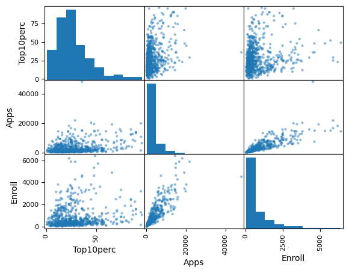

```python
pd.plotting.scatter_matrix(college[['Top10perc', 'Apps', 'Enroll']]);
```

#### Part E

Use the boxplot() method of college to produce side-by-side boxplots of Outstate versus Private.

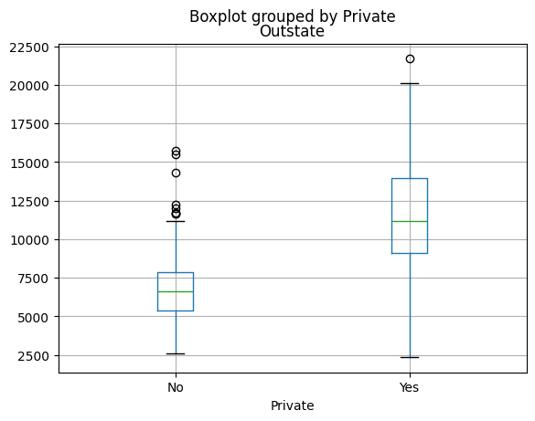

```python
college.boxplot('Outstate','Private');
```

Part F

Create a new qualitative variable, called Elite, by binning the Top10perc variable into two groups based on whether or not the proportion of students coming from the top 10% of their high school classes exceeds 50%.

```
college['Elite'] = pd.cut(college[ 'Top10perc'],
[0,0.5,1],
labels=['No', 'Yes'])
```

Use the value_counts() method of college['Elite'] to see how many elite universities there are. Finally, use the boxplot() method again to produce side-by-side boxplots of Outstate versus Elite.

```python
college['Elite'] = pd.cut(college[ 'Top10perc'],[0,0.5,1],labels=['No', 'Yes'])
```

```python
college['Elite'].value_counts()
```

```
Elite
Yes    3
No     0
Name: count, dtype: int64
```

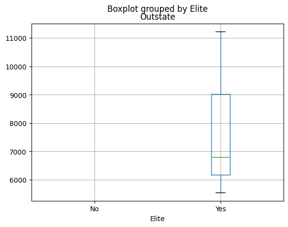

```python
college.boxplot('Outstate', 'Elite');
```

```python
import matplotlib.pyplot as plt
```

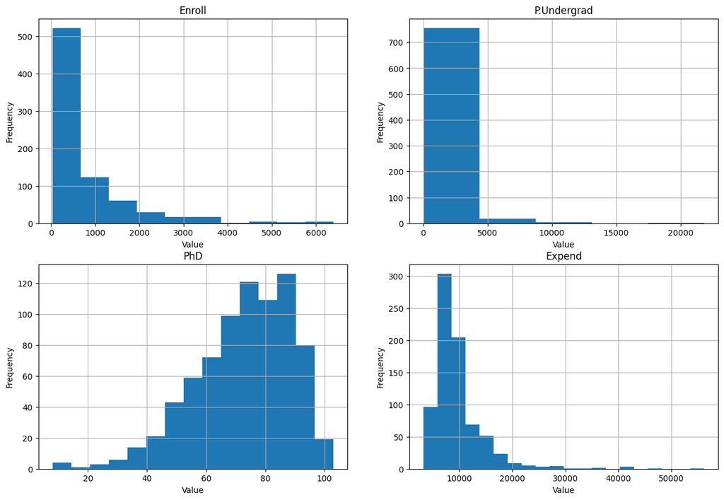

```python
fig, axes = plt.subplots(2, 2, figsize=(15,10));

college['Enroll'].hist(ax=axes[0,0],bins = 10);
axes[0,0].set_title('Enroll');
axes[0,0].set_xlabel('Value');
axes[0,0].set_ylabel('Frequency');

college['P.Undergrad'].hist(ax=axes[0,1],bins = 5);
axes[0,1].set_title('P.Undergrad');
axes[0,1].set_xlabel('Value');
axes[0,1].set_ylabel('Frequency');

college['PhD'].hist(ax=axes[1,0],bins = 15);
axes[1,0].set_title('PhD');
axes[1,0].set_xlabel('Value');
axes[1,0].set_ylabel('Frequency');

college['Expend'].hist(ax=axes[1,1],bins = 20);
axes[1,1].set_title('Expend');
axes[1,1].set_xlabel('Value');
axes[1,1].set_ylabel('Frequency');
```

Part H

Continue exploring the data, and provide a brief summary of what you discover.

**I am particularly interested in the relationship between expenditure and percentage of faculty with PhDs. Let's explore that relationship.**

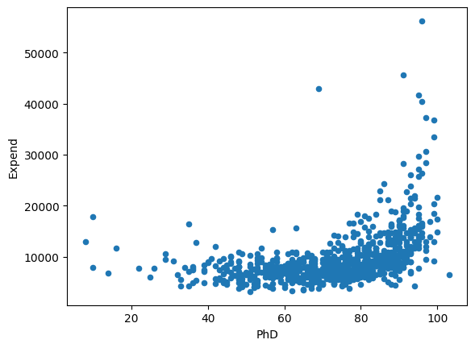

```python
college.plot.scatter(x='PhD', y='Expend');
```

**Interesting, this is similar to what I was expecting, but I thought the relationship would be more linear. Let's see id the proportion of PhD professors affects graduation rate.**

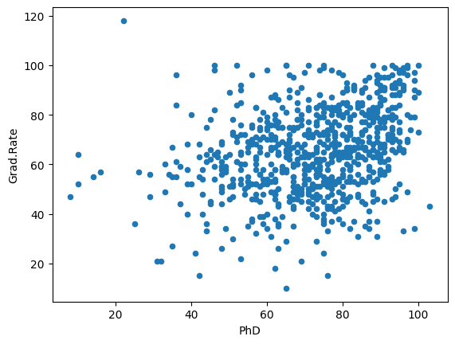

```python
college.plot.scatter(x='PhD', y='Grad.Rate');
```

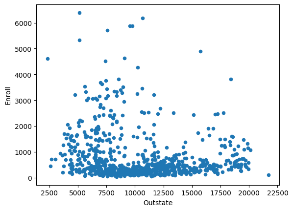

```python
college.plot.scatter(x='Outstate', y='Enroll');
```

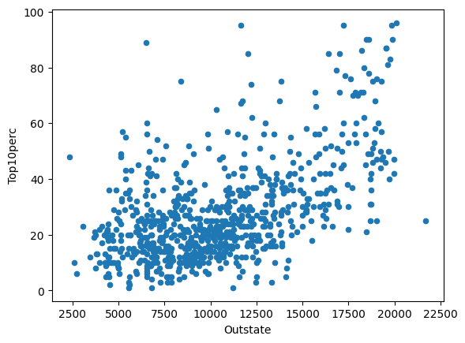

```python
college.plot.scatter(x='Outstate', y='Top10perc');
```

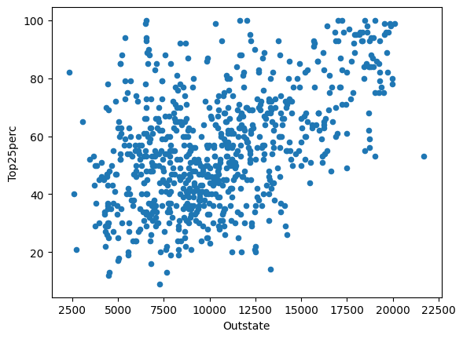

```python
college.plot.scatter(x='Outstate', y='Top25perc');
```

```python
college['Accept.Rate'] = college['Accept']/college['Apps']
```

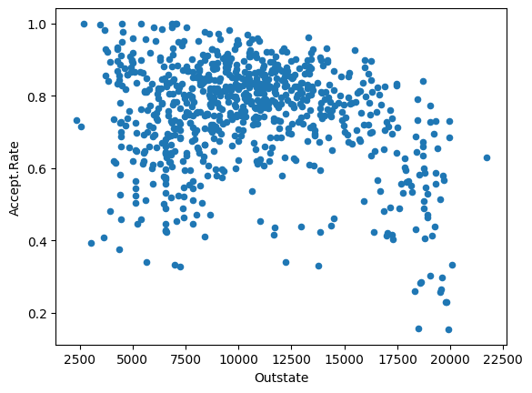

```python
college.plot.scatter(x='Outstate', y='Accept.Rate');
```

**There were several trends that I was interested in exploring, and most of them behaved as expected.**

- The first relationship, Outstate vs Enroll, did not show a clear trend. I was expecting this to be negatively correlated, but I didn't adjust for the total number of students at the institution, so this result is conflated with other factors.
- The second relationship, Outstate vs Top10perc, was moderately positively correlated, which is what I was expecting. As with any product or service, more expensive is generally considered more premium or better, so I expected expensive institutions to attract the best highschool applicants.
- The third relationship, Outstate vs Top25perc, was also moderatly positively correlated, for the same reason outlined in my Top10perc analysis.
- The final relationship, Outstate vs Acceptance Rate, was slightly negatively correlated, as expected. The more expensive the institution, the more selective it might be.

## Problem 9

This exercise involves the Auto data set studied in the lab. Make sure that the missing values have been removed from the data.

```python
# Before getting started, identify and remove the missing data.
# From looking at the csv, I found that horsepower has missing values.
# These are question marks in the dataset, so we will drop that as well.
data_path = './data/Auto.csv'
auto = pd.read_csv(data_path)
auto.dropna(axis=0, how='any')
auto = auto[auto['horsepower'] != '?']
```

```python
# Origin also needs to be remapped. It is currently using a numerical representation
# to describe the region of origin, which is not ideal. Let's resolve this.

origin_map = {1:'American',
             2:'European',
             3:'Japanese'}

remapped = []

for region in auto['origin']:
    remapped.append(origin_map[region])

auto['origin'] = pd.Series(remapped)
```

### Part A

Which of the predictors are quantitative, and which are qualitative?

```python
quantitative = auto.describe().columns
qualitative = [column for column in auto.columns if column not in quantitative]
```

```python
quantitative
```

```
Index(['mpg', 'cylinders', 'displacement', 'weight', 'acceleration', 'year'], dtype='object')
```

```python
qualitative
```

```
['horsepower', 'origin', 'name']
```

**Hmmmmm, this doesn't match what I was expecting. Let's look at the type of each column.**

```python
for column in auto.columns:
    print(column, auto[column].dtype)
```

```
mpg float64
cylinders int64
displacement float64
horsepower object
weight int64
acceleration float64
year int64
origin object
name object
```

**Okay, so here is the root of the issue. Let's go through and change the types of the columns that should be quantitative.**

```python
auto['horsepower'] = auto['horsepower'].astype('int64')
```

**Now the steps from before can be repeated.**

```python
quantitative = auto.describe().columns
qualitative = [column for column in auto.columns if column not in quantitative]
```

```python
quantitative
```

```
Index(['mpg', 'cylinders', 'displacement', 'horsepower', 'weight',
       'acceleration', 'year'],
      dtype='object')
```

```python
qualitative
```

```
['origin', 'name']
```

### Part B

What is the range of each quantitative predictor? You can answer this using the min() and max() methods in numpy.

```python
for column in quantitative:
    print(f'Range of {column}: {min(auto[column])} - {max(auto[column])}')
```

```
Range of mpg: 9.0 - 46.6
Range of cylinders: 3 - 8
Range of displacement: 68.0 - 455.0
Range of horsepower: 46 - 230
Range of weight: 1613 - 5140
Range of acceleration: 8.0 - 24.8
Range of year: 70 - 82
```

### Part C

What is the mean and standard deviation of each quantitative predictor?

```python
for column in quantitative:
    print(f"{column} Mean: {round(auto[column].mean(), 2)}\n{column} Standard Deviation: {round(auto[column].std(), 2)}\n")
```

```
mpg Mean: 23.45
mpg Standard Deviation: 7.81

cylinders Mean: 5.47
cylinders Standard Deviation: 1.71

displacement Mean: 194.41
displacement Standard Deviation: 104.64

horsepower Mean: 104.47
horsepower Standard Deviation: 38.49

weight Mean: 2977.58
weight Standard Deviation: 849.4

acceleration Mean: 15.54
acceleration Standard Deviation: 2.76

year Mean: 75.98
year Standard Deviation: 3.68
```

### Part D

Now remove the 10th through 85th observations. What is the range, mean, and standard deviation of each predictor in the subset of the data that remains?

```python
len(auto)
```

```
392
```

```python
auto_subset = auto.drop(auto.index[10:85], axis = 0)
```

```python
len(auto_subset)
```

```
317
```

```python
for column in quantitative:
    print(f'Range of {column}: {min(auto_subset[column])} - {max(auto_subset[column])}')
```

```
Range of mpg: 11.0 - 46.6
Range of cylinders: 3 - 8
Range of displacement: 68.0 - 455.0
Range of horsepower: 46 - 230
Range of weight: 1649 - 4997
Range of acceleration: 8.5 - 24.8
Range of year: 70 - 82
```

```python
for column in quantitative:
    print(f"{column} Mean: {round(auto_subset[column].mean(), 2)}\n{column} Standard Deviation: {round(auto_subset[column].std(), 2)}\n")
```

```
mpg Mean: 24.37
mpg Standard Deviation: 7.87

cylinders Mean: 5.38
cylinders Standard Deviation: 1.66

displacement Mean: 187.88
displacement Standard Deviation: 100.17

horsepower Mean: 101.0
horsepower Standard Deviation: 36.0

weight Mean: 2938.85
weight Standard Deviation: 811.64

acceleration Mean: 15.7
acceleration Standard Deviation: 2.72

year Mean: 77.12
year Standard Deviation: 3.13
```

### Part E

Using the full data set, investigate the predictors graphically, using scatterplots or other tools of your choice. Create some plots highlighting the relationships among the predictors. Comment on your findings.

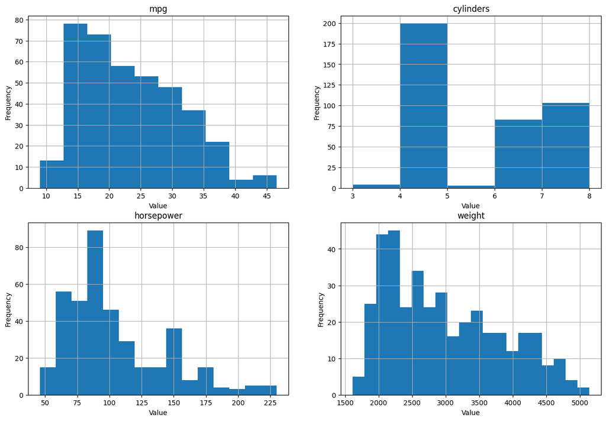

```python
fig, axes = plt.subplots(2, 2, figsize=(15,10));

auto['mpg'].hist(ax=axes[0,0],bins = 10);
axes[0,0].set_title('mpg');
axes[0,0].set_xlabel('Value');
axes[0,0].set_ylabel('Frequency');

auto['cylinders'].hist(ax=axes[0,1],bins = 5);
axes[0,1].set_title('cylinders');
axes[0,1].set_xlabel('Value');
axes[0,1].set_ylabel('Frequency');

auto['horsepower'].hist(ax=axes[1,0],bins = 15);
axes[1,0].set_title('horsepower');
axes[1,0].set_xlabel('Value');
axes[1,0].set_ylabel('Frequency');

auto['weight'].hist(ax=axes[1,1],bins = 20);
axes[1,1].set_title('weight');
axes[1,1].set_xlabel('Value');
axes[1,1].set_ylabel('Frequency');
```

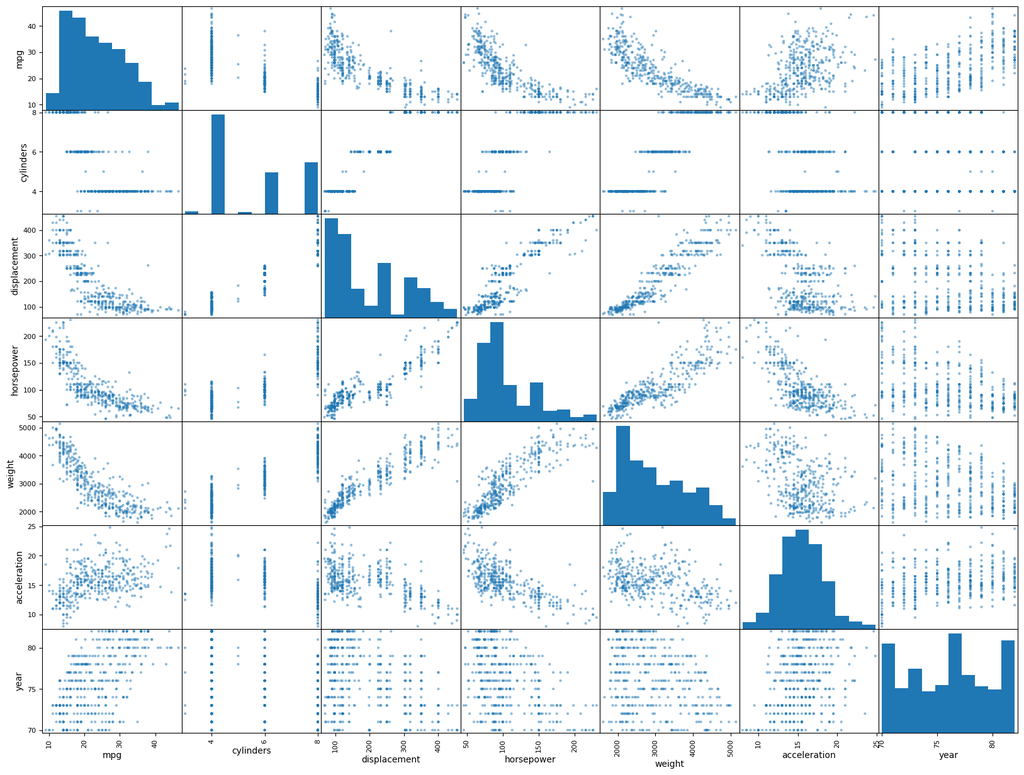

```python
pd.plotting.scatter_matrix(auto[quantitative], figsize=(20, 15));
```

**There are several interesting trends in these variables. Most notably, displacement vs horsepower, mpg vs weight, and mpg vs year.**

- Displacment vs Horsepower:
  - This is nearly a perfectly linear, positively correlated variable.
- MPG vs Weight:
  - This appears to have a relationship that resembles exponential decay. MPG is inversely proportional to Weight.
- MPG vs Year:
  - MPG and Year appear to be moderately positively correlated, which is likely due to design improvements and efficiency regulations.

### Part F

Suppose that we wish to predict gas mileage (mpg) on the basis of the other variables. Do your plots suggest that any of the other variables might be useful in predicting mpg? Justify your answer.

**The plots, above, suggest displacement, horsepower, and weight are strong predictors of gas mileage, while acceleration is a weak predictor. The strong predictors are all negatively correlated with MPG, and each relationship can be categorized as 'exponential decay.' Acceleration time is positively correlated with mpg, which is an intuitive relationship based on how acceleration is correlated with the other factors.**

## Problem 10

This exercise involves the Boston housing data set.

### Part A

To begin, load in the Boston data set, which is part of the ISLP library.

```python
from ISLP import load_data
```

```python
boston = load_data('Boston')
```

### Part B

How many rows are in this data set? How many columns? What do the rows and columns represent?

```python
boston.info()
```

```
<class 'pandas.core.frame.DataFrame'>
RangeIndex: 506 entries, 0 to 505
Data columns (total 13 columns):
 #   Column   Non-Null Count  Dtype
---  ------   --------------  -----
 0   crim     506 non-null    float64
 1   zn       506 non-null    float64
 2   indus    506 non-null    float64
 3   chas     506 non-null    int64
 4   nox      506 non-null    float64
 5   rm       506 non-null    float64
 6   age      506 non-null    float64
 7   dis      506 non-null    float64
 8   rad      506 non-null    int64
 9   tax      506 non-null    int64
 10  ptratio  506 non-null    float64
 11  lstat    506 non-null    float64
 12  medv     506 non-null    float64
dtypes: float64(10), int64(3)
memory usage: 51.5 KB
```

From the ISLP website for this dataset (https://intro-stat-learning.github.io/ISLP/datasets/Boston.html)

crim: per capita crime rate by town.

zn: proportion of residential land zoned for lots over 25,000 sq.ft.

indus: proportion of non-retail business acres per town.

chas: Charles River dummy variable (= 1 if tract bounds river; 0 otherwise).

nox: nitrogen oxides concentration (parts per 10 million).

rm: average number of rooms per dwelling.

age: proportion of owner-occupied units built prior to 1940.

dis: weighted mean of distances to five Boston employment centres.

rad: index of accessibility to radial highways.

tax: full-value property-tax rate per $10,000.

ptratio: pupil-teacher ratio by town.

lstat: lower status of the population (percent).

medv: median value of owner-occupied homes in $1000s.

### Part C

Make some pairwise scatterplots of the predictors (columns) in this data set. Describe your findings.

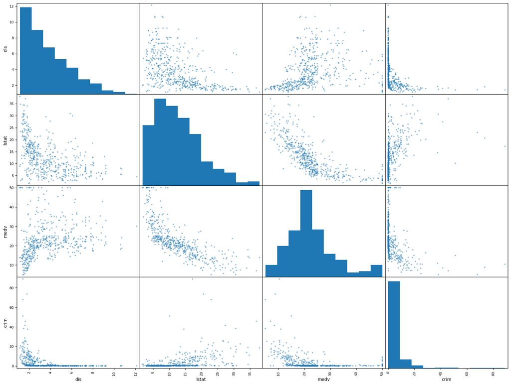

```python
pd.plotting.scatter_matrix(boston[['dis', 'lstat', 'medv', 'crim']], figsize=(20, 15));
```

**These columns were selected because my hypothesis was the weighted mean of distances to five Boston employment centers would be correlated with the other predictors. I found that there were correlations with the other variables, but not what I expected.**

- Dis vs Lstat:
  - This was negatively, exponentially related. I expected positive, linear correlation.
- Dis vs Medv:
  - This was positively, logarithmically related. I expected negative, linear correlation.
- Dis vs Crim:
  - This was negatively, exponentially related. I expected negative, linear correlation.

The key takeaway from my poor assumption is that population density is probably the driving variable.

### Part D

Are any of the predictors associated with per capita crime rate? If so, explain the relationship.

**As seen in the previous scatter matrix, 'dis' is associated with crime rate. My assumption is that 'dis' is actually a strong predictor for population density.**

### Part E

Do any of the suburbs of Boston appear to have particularly high crime rates? Tax rates? Pupil-teacher ratios? Comment on the range of each predictor.

```python
boston['crim'].sort_values(ascending=False).head(10)
```

```
380    88.9762
418    73.5341
405    67.9208
410    51.1358
414    45.7461
404    41.5292
398    38.3518
427    37.6619
413    28.6558
417    25.9406
Name: crim, dtype: float64
```

```python
boston['tax'].sort_values(ascending=False).head(10)
```

```
492    711
491    711
490    711
489    711
488    711
405    666
452    666
456    666
455    666
454    666
Name: tax, dtype: int64
```

```python
boston['ptratio'].sort_values(ascending=False).head(10)
```

```
354    22.0
355    22.0
135    21.2
127    21.2
136    21.2
141    21.2
139    21.2
138    21.2
137    21.2
140    21.2
Name: ptratio, dtype: float64
```

```python
for column in boston.columns:
    print(f'Mean {column} Value: {boston[column].mean()}\tMedian {column} Value: {boston[column].median()}')
```

```
Mean crim Value: 3.613523557312254	Median crim Value: 0.25651
Mean zn Value: 11.363636363636363	Median zn Value: 0.0
Mean indus Value: 11.13677865612648	Median indus Value: 9.69
Mean chas Value: 0.0691699604743083	Median chas Value: 0.0
Mean nox Value: 0.5546950592885376	Median nox Value: 0.538
Mean rm Value: 6.284634387351779	Median rm Value: 6.2085
Mean age Value: 68.57490118577076	Median age Value: 77.5
Mean dis Value: 3.795042687747036	Median dis Value: 3.2074499999999997
Mean rad Value: 9.549407114624506	Median rad Value: 5.0
Mean tax Value: 408.2371541501976	Median tax Value: 330.0
Mean ptratio Value: 18.455533596837945	Median ptratio Value: 19.05
Mean lstat Value: 12.653063241106722	Median lstat Value: 11.36
Mean medv Value: 22.532806324110677	Median medv Value: 21.2
```

### Part F

How many of the suburbs in this data set bound the Charles river?

```python
len(boston[boston['chas'] == 1])
```

```
35
```

**35 of the suburbs are bound to the Charles River.**

### Part G

What is the median pupil-teacher ratio among the towns in this data set?

```python
boston['ptratio'].median()
```

```
19.05
```

### Part H

Which suburb of Boston has lowest median value of owner-occupied homes? What are the values of the other predictors for that suburb, and how do those values compare to the overall ranges for those predictors? Comment on your findings.

```python
boston['medv'].sort_values().head(1)
```

```
398    5.0
Name: medv, dtype: float64
```

```python
boston.iloc[398]
```

```
crim        38.3518
zn           0.0000
indus       18.1000
chas         0.0000
nox          0.6930
rm           5.4530
age        100.0000
dis          1.4896
rad         24.0000
tax        666.0000
ptratio     20.2000
lstat       30.5900
medv         5.0000
Name: 398, dtype: float64
```

```python
for column in boston.columns:
    print(f'Minimum {column} Value: {min(boston[column])}\t\tMaximum {column} Value: {max(boston[column])}\t\tMean {column} Value: {boston[column].mean()}')
```

```
Minimum crim Value: 0.00632		Maximum crim Value: 88.9762		Mean crim Value: 3.613523557312254
Minimum zn Value: 0.0		Maximum zn Value: 100.0		Mean zn Value: 11.363636363636363
Minimum indus Value: 0.46		Maximum indus Value: 27.74		Mean indus Value: 11.13677865612648
Minimum chas Value: 0		Maximum chas Value: 1		Mean chas Value: 0.0691699604743083
Minimum nox Value: 0.385		Maximum nox Value: 0.871		Mean nox Value: 0.5546950592885376
Minimum rm Value: 3.561		Maximum rm Value: 8.78		Mean rm Value: 6.284634387351779
Minimum age Value: 2.9		Maximum age Value: 100.0		Mean age Value: 68.57490118577076
Minimum dis Value: 1.1296		Maximum dis Value: 12.1265		Mean dis Value: 3.795042687747036
Minimum rad Value: 1		Maximum rad Value: 24		Mean rad Value: 9.549407114624506
Minimum tax Value: 187		Maximum tax Value: 711		Mean tax Value: 408.2371541501976
Minimum ptratio Value: 12.6		Maximum ptratio Value: 22.0		Mean ptratio Value: 18.455533596837945
Minimum lstat Value: 1.73		Maximum lstat Value: 37.97		Mean lstat Value: 12.653063241106722
Minimum medv Value: 5.0		Maximum medv Value: 50.0		Mean medv Value: 22.532806324110677
```

**These predictors tend to be on the worse end of the range for suburb 398. It has relatively high crime, low number of rooms per dwelling, and a high value for lower status of the population. Each of these values was compared to the mean of all suburbs.**

### Part I

In this data set, how many of the suburbs average more than seven rooms per dwelling? More than eight rooms per dwelling? Comment on the suburbs that average more than eight rooms per dwelling.

```python
len(boston[boston['rm']>7])
```

```
64
```

```python
boston[boston['rm']>8]
```

|  | crim | zn | indus | chas | nox | rm | age | dis | rad | tax | ptratio | lstat | medv |
| --- | --- | --- | --- | --- | --- | --- | --- | --- | --- | --- | --- | --- | --- |
| 97 | 0.12083 | 0.0 | 2.89 | 0 | 0.4450 | 8.069 | 76.0 | 3.4952 | 2 | 276 | 18.0 | 4.21 | 38.7 |
| 163 | 1.51902 | 0.0 | 19.58 | 1 | 0.6050 | 8.375 | 93.9 | 2.1620 | 5 | 403 | 14.7 | 3.32 | 50.0 |
| 204 | 0.02009 | 95.0 | 2.68 | 0 | 0.4161 | 8.034 | 31.9 | 5.1180 | 4 | 224 | 14.7 | 2.88 | 50.0 |
| 224 | 0.31533 | 0.0 | 6.20 | 0 | 0.5040 | 8.266 | 78.3 | 2.8944 | 8 | 307 | 17.4 | 4.14 | 44.8 |
| 225 | 0.52693 | 0.0 | 6.20 | 0 | 0.5040 | 8.725 | 83.0 | 2.8944 | 8 | 307 | 17.4 | 4.63 | 50.0 |
| 226 | 0.38214 | 0.0 | 6.20 | 0 | 0.5040 | 8.040 | 86.5 | 3.2157 | 8 | 307 | 17.4 | 3.13 | 37.6 |
| 232 | 0.57529 | 0.0 | 6.20 | 0 | 0.5070 | 8.337 | 73.3 | 3.8384 | 8 | 307 | 17.4 | 2.47 | 41.7 |
| 233 | 0.33147 | 0.0 | 6.20 | 0 | 0.5070 | 8.247 | 70.4 | 3.6519 | 8 | 307 | 17.4 | 3.95 | 48.3 |
| 253 | 0.36894 | 22.0 | 5.86 | 0 | 0.4310 | 8.259 | 8.4 | 8.9067 | 7 | 330 | 19.1 | 3.54 | 42.8 |
| 257 | 0.61154 | 20.0 | 3.97 | 0 | 0.6470 | 8.704 | 86.9 | 1.8010 | 5 | 264 | 13.0 | 5.12 | 50.0 |
| 262 | 0.52014 | 20.0 | 3.97 | 0 | 0.6470 | 8.398 | 91.5 | 2.2885 | 5 | 264 | 13.0 | 5.91 | 48.8 |
| 267 | 0.57834 | 20.0 | 3.97 | 0 | 0.5750 | 8.297 | 67.0 | 2.4216 | 5 | 264 | 13.0 | 7.44 | 50.0 |
| 364 | 3.47428 | 0.0 | 18.10 | 1 | 0.7180 | 8.780 | 82.9 | 1.9047 | 24 | 666 | 20.2 | 5.29 | 21.9 |

**These subrubs appear to be wealthier and safer based on lstat, medv, and crim. Surprisingly, these wealthy suburbs also have some of the lowest tax rates of all suburbs, which is the opposite of what I would expect.**